# PS5: markdown and basic plots

Kyra Diaz

2/13/2023

# Load and check data (5pt)

You first task is to do a very simple data check:

**1. (1pt) For solving the problems, and answering the questions, create a new rmarkdown document with an appropriate title. See [**https://faculty.washington.edu/otoomet/info201-book/r-markdown.html#r-markdown-rstudio-creating**](https://faculty.washington.edu/otoomet/info201-book/r-markdown.html#r-markdown-rstudio-creating).**

**2. (2pt) Load data. How many rows/columns do we have?**

```r
library(tidyverse)

gap <- read_delim("gapminder.csv.bz2")

nrow(gap)
```

```
## [1] 13055
```

```r
ncol(gap)
```

```
## [1] 25
```

The *Gapminder* dataset has 13055 rows and 25 columns.

**3. (2pt) Print a small sample of data. Does it look OK?**

Here’s a sample of the data:

```r
gap %>%
  sample_n(5)
```

```
## # A tibble: 5 × 25
##   iso3  name  iso2  region sub-r…¹ inter…²  time total…³ ferti…⁴ lifeE…⁵ child…⁶
##   <chr> <chr> <chr> <chr>  <chr>   <chr>   <dbl>   <dbl>   <dbl>   <dbl>   <dbl>
## 1 PRI   Puer… PR    Ameri… Latin … Caribb…  2014  3.53e6    1.43    79.2    NA
## 2 GUM   Guam  GU    Ocean… Micron… <NA>     1977  9.75e4    3.56    68.3    NA
## 3 KOR   Kore… KR    Asia   Easter… <NA>     1963  2.73e7    5.53    57.0    96.8
## 4 ISR   Isra… IL    Asia   Wester… <NA>     1997  5.84e6    2.94    78       7.8
## 5 NOR   Norw… NO    Europe Northe… <NA>     1962  3.64e6    2.91    73.4    21.6
## # … with 14 more variables: youthFemaleLiteracy <dbl>, youthMaleLiteracy <dbl>,
## #   adultLiteracy <dbl>, GDP_PC <dbl>, accessElectricity <dbl>,
## #   agriculturalLand <dbl>, agricultureTractors <dbl>, cerealProduction <dbl>,
## #   fertilizerHa <dbl>, co2 <dbl>, greenhouseGases <dbl>, co2_PC <dbl>,
## #   pm2.5_35 <dbl>, battleDeaths <dbl>, and abbreviated variable names
## #   ¹`sub-region`, ²`intermediate-region`, ³totalPopulation, ⁴fertilityRate,
## #   ⁵lifeExpectancy, ⁶childMortality
```

It looks good!

# Descriptive statistics (15pt)

**1. (3pt) How many countries are there in the dataset? Analyze all three: *iso3*, *iso2* and *name*.**

```r
gap %>%
  summarize(countries = n_distinct(name),
            n_iso2 = n_distinct(iso2),
            n_iso3 = n_distinct(iso3))
```

```
## # A tibble: 1 × 3
##   countries n_iso2 n_iso3
##       <int>  <int>  <int>
## 1       250    249    253
```

There seems to be 250 countries, 249 iso-2 codes, and 253 iso-3 country codes.

**2. If you did this correctly, you saw that there are more iso-2 codes than names, and there are even more *iso3*-codes. What is going on? Can you find it out?**

**(a) (5pt) Find how many names are there for each iso-2 code. Are there any iso-2 codes that correspond to more than one name? What are these countries?**

```r
gap %>%
  group_by(name) %>%
  summarize(iso2_countries = n_distinct(iso2)) %>%
  arrange(desc(iso2_countries))
```

```
## # A tibble: 250 × 2
##    name                iso2_countries
##    <chr>                        <int>
##  1 Afghanistan                      1
##  2 Albania                          1
##  3 Algeria                          1
##  4 American Samoa                   1
##  5 Andorra                          1
##  6 Angola                           1
##  7 Anguilla                         1
##  8 Antarctica                       1
##  9 Antigua and Barbuda              1
## 10 Argentina                        1
## # … with 240 more rows
```

There are no iso-2 codes that correspond to more than one country.

**(b) (5pt) Now repeat the same for name and iso3-code. Are there country names that have more than one iso3-code? What are these countries? Hint: two of these entitites are *CHANISL* and *NLD CURACAO*.**

```r
gap %>%
  group_by(name) %>%
  summarize(iso3_countries = n_distinct(iso3)) %>%
  arrange(desc(iso3_countries))
```

```
## # A tibble: 250 × 2
##    name                iso3_countries
##    <chr>                        <int>
##  1 <NA>                             4
##  2 Afghanistan                      1
##  3 Albania                          1
##  4 Algeria                          1
##  5 American Samoa                   1
##  6 Andorra                          1
##  7 Angola                           1
##  8 Anguilla                         1
##  9 Antarctica                       1
## 10 Antigua and Barbuda              1
## # … with 240 more rows
```

It seems that there are four iso3 codes that do not have a country assigned to them (instead, they’re labeled “NA”). We can check which iso3 codes these are by doing the following:

```r
gap %>%
  filter(is.na(name)) %>%
  group_by(name) %>%
  distinct(iso3)
```

```
## # A tibble: 4 × 2
## # Groups:   name [1]
##   name  iso3
##   <chr> <chr>
## 1 <NA>  CHANISL
## 2 <NA>  GBM
## 3 <NA>  KOS
## 4 <NA>  NLD_CURACAO
```

According to the code, the iso3 codes with no country include CHANISL, GBM, KOS, and NLD_CURACAO.

**3. (2pt) What is the minimum and maximum year in these data?**

```r
min_yr <- gap %>%
  select(time) %>%
  filter(!is.na(time)) %>%
  min()

min_yr
```

```
## [1] 1960
```

```r
max_yr <- gap %>%
  select(time) %>%
  filter(!is.na(time)) %>%
  max()

max_yr
```

```
## [1] 2019
```

The minimum year is 1960 and the maximum year is 2019.

# CO2 emissions (30pt)

Next, let’s analyze CO2 emissions.

**1. (2pt) How many missing co2 emissions are there for each year? Analyze both missing *CO2* and *co2_PC*. Which years have most missing data?**

```r
 gap %>%
  select(time, co2, co2_PC) %>%
  group_by(time) %>%
  filter(is.na(co2_PC), is.na(co2)) %>%
  count() %>%
  arrange(desc(n))
```

```
## # A tibble: 61 × 2
## # Groups:   time [61]
##     time     n
##    <dbl> <int>
##  1  2017   217
##  2  2018   217
##  3  2019   217
##  4  1960    60
##  5  1961    60
##  6  1962    58
##  7  1963    57
##  8  1964    51
##  9  1965    51
## 10  1966    51
## # … with 51 more rows
```

2017, 2018, and 2019 have the most missing co2 emissions with a frequency of 217.

**2. (5pt) Make a plot of total CO2 emissions over time for the U.S, China, and India. Add a few more countries of your choice. Explain what do you see.**

First, I made a subset with the countries I wanted to plot:

```r
co2_countries <- c("China", "United States of America", "India", "Philippines", "Mexico", "France")

co2_gap <- gap %>%
  filter(name %in% co2_countries) %>%
  filter(!is.na(co2))
```

Then, I plotted these points:

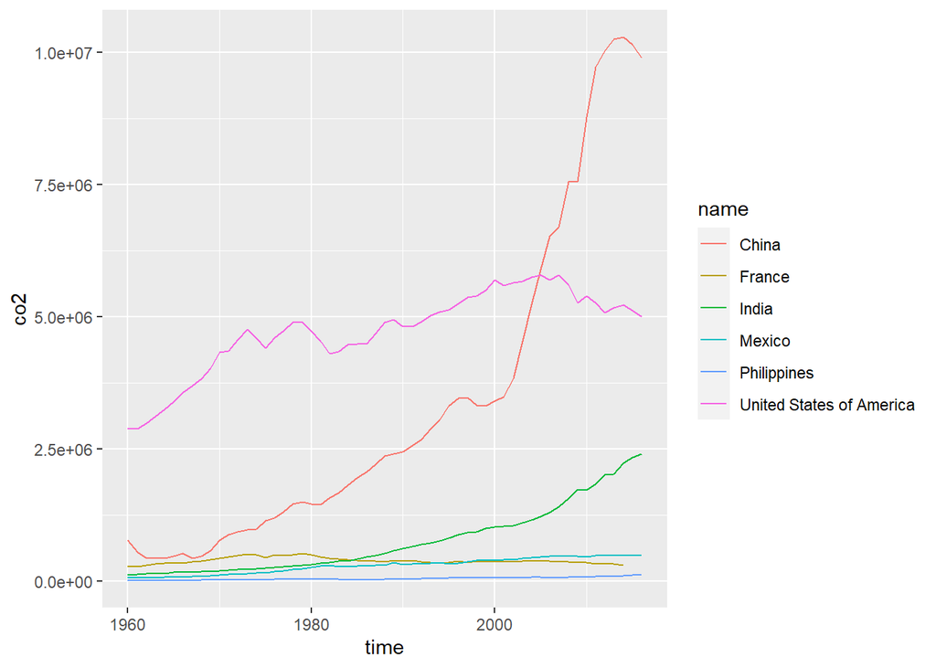

```r
ggplot(co2_gap) +
  geom_line(aes(x = time, y = co2,
                group = name,
                color = name))
```

Looking at the data, we can see clearly that China’s CO2 emissions have increased a lot more than other countries over time. In addition, the U.S. seems to have higher levels of CO2 emissions overall, though hasn’t increased as much as China. India also has upward trends of CO2 emissions, but Mexico, Philippines, and France have remained pretty constant.

**3. (5pt) Now let’s analyze the CO2 emissions per capita (*co2_PC*). Make a similar plot of the same countries. What does this figure suggest?**

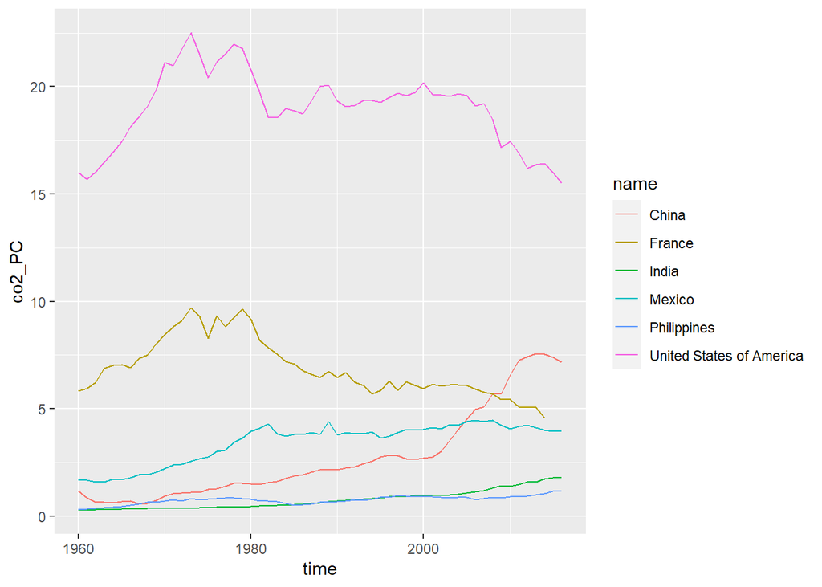

```r
ggplot(co2_gap) +
  geom_line(aes(x = time, y = co2_PC,
                group = name,
                color = name))
```

Overall,the U.S. has a higher rate of CO2 emissions per capita France, Mexico, China, Philippines, and India.

**4. (6pt) Compute average CO2 emissions per capita across the continents (assume *region* is the same as continent). Comment what do you see.**  
**Note: just compute averages over countries and ignore the fact that countries are of different size.**  
**Hint: Americas 2016 should be 4.80.**

```r
co2_regions <- gap %>%
  group_by(time, region) %>%
  filter(!is.na(co2_PC), !is.na(region)) %>%
  mutate(avg_co2PC = mean(co2_PC)) %>%
  select(region, time, avg_co2PC) %>%
  arrange(desc(time))

head(co2_regions, 8)
```

```
## # A tibble: 8 × 3
## # Groups:   time, region [4]
##   region    time avg_co2PC
##   <chr>    <dbl>     <dbl>
## 1 Americas  2016      4.80
## 2 Asia      2016      6.47
## 3 Africa    2016      1.20
## 4 Europe    2016      6.64
## 5 Europe    2016      6.64
## 6 Asia      2016      6.47
## 7 Americas  2016      4.80
## 8 Asia      2016      6.47
```

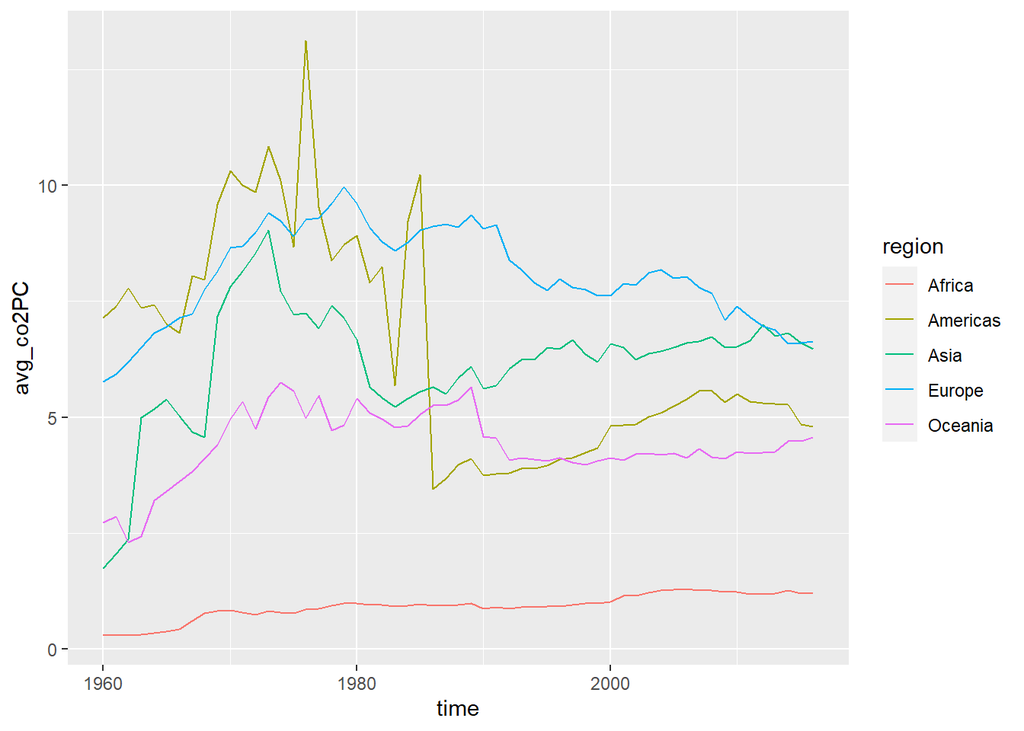

```r
ggplot(co2_regions) +
  geom_line(aes(x = time, y = avg_co2PC,
                group = region,
                color = region))
```

**5. (7pt) Make a barplot where you show the previous results–average CO2 emissions per capita across continents in 1960 and 2016.**  
**Hint: it should look something along these lines(Please refer to the spec for the graph)**

```r
avgco2 <- gap %>%
  select(region, co2_PC, time) %>%
  filter(!is.na(region), time %in% c("1960", "2016")) %>%
  group_by(region, time) %>%
  summarize(avg_co2PC = mean(co2_PC, na.rm = TRUE))
```

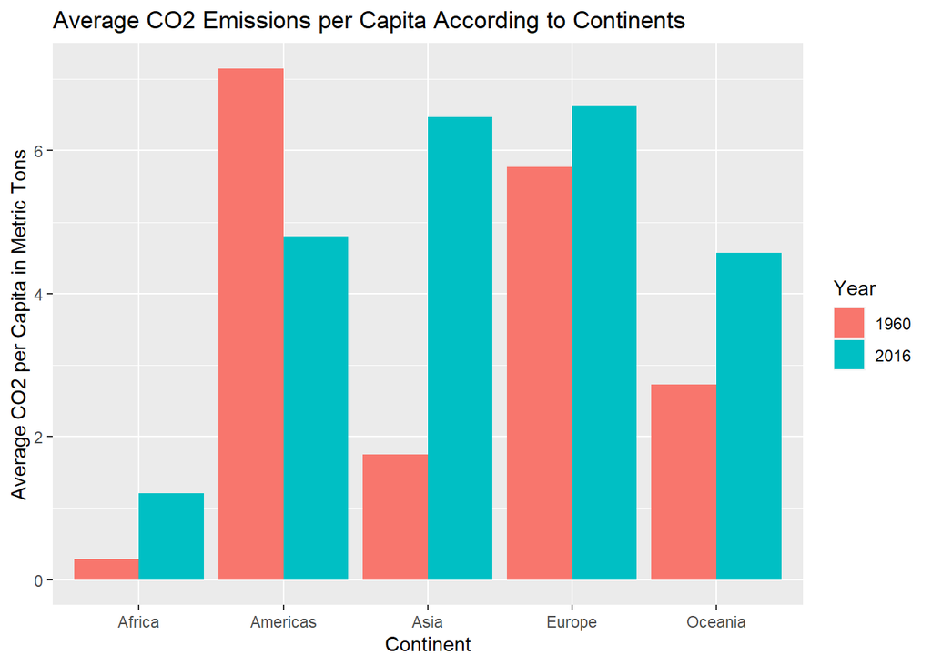

```r
ggplot(avgco2, aes(region, avg_co2PC, fill = factor(time))) +
  geom_col(position = "dodge") +
  labs(title = "Average CO2 Emissions per Capita According to Continents",
       x = "Continent",
       y = "Average CO2 per Capita in Metric Tons",
       fill = "Year"
       )
```

**6. Which countries are the three largest, and three smallest CO2 emitters (in terms of CO2 per capita) in 2019 for each continent? (Assume *region* is continent).**

```r
gap %>%
  filter(time == "2019", !is.na(region)) %>%
  group_by(region) %>%
  arrange(co2_PC) %>%
  slice_head(n = 3) %>%
  select(region, name)
```

```
## # A tibble: 15 × 2
## # Groups:   region [5]
##    region   name
##    <chr>    <chr>
##  1 Africa   Angola
##  2 Africa   Burundi
##  3 Africa   Benin
##  4 Americas Aruba
##  5 Americas Argentina
##  6 Americas Antigua and Barbuda
##  7 Asia     Afghanistan
##  8 Asia     United Arab Emirates
##  9 Asia     Armenia
## 10 Europe   Albania
## 11 Europe   Andorra
## 12 Europe   Austria
## 13 Oceania  American Samoa
## 14 Oceania  Australia
## 15 Oceania  Fiji
```

```r
gap %>%
  filter(time == "2019", !is.na(region)) %>%
  group_by(region) %>%
  arrange(co2_PC) %>%
  slice_tail(n = 3) %>%
  select(region, name)
```

```
## # A tibble: 15 × 2
## # Groups:   region [5]
##    region   name
##    <chr>    <chr>
##  1 Africa   South Africa
##  2 Africa   Zambia
##  3 Africa   Zimbabwe
##  4 Americas Venezuela (Bolivarian Republic of)
##  5 Americas Virgin Islands (British)
##  6 Americas Virgin Islands (U.S.)
##  7 Asia     Uzbekistan
##  8 Asia     Viet Nam
##  9 Asia     Yemen
## 10 Europe   Slovenia
## 11 Europe   Sweden
## 12 Europe   Ukraine
## 13 Oceania  Tuvalu
## 14 Oceania  Vanuatu
## 15 Oceania  Samoa
```

# GDP per capita (50pt)

Let’s look at GDP per capita (*GDP_PC*)

**1. (8pt) Make a scatterplot of GDP per capita versus life expectancy by country, using data for 1960. Make the point size dependent on** **the country size, and color those according to the continent. Feel free to adjust the plot in other ways to make it better.**  
**Comment what do you see there.**

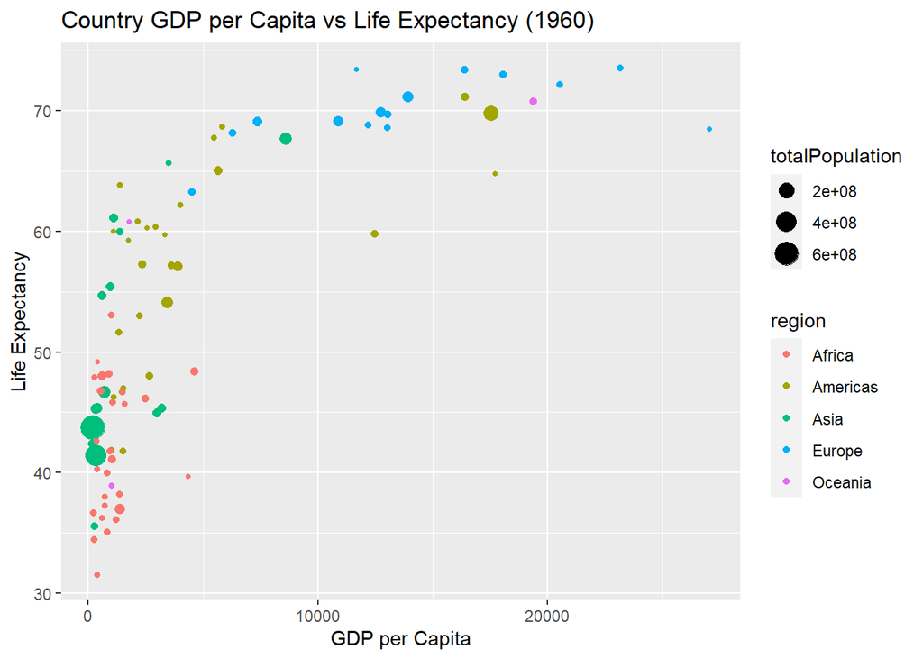

```r
gap_1960 <- gap %>%
  filter(time == "1960",
         !is.na(name),
         !is.na(region),
         !is.na(GDP_PC),
         !is.na(totalPopulation),
         !is.na(lifeExpectancy))

ggplot(gap_1960, aes(GDP_PC, lifeExpectancy)) +
  geom_point(aes(group = region,
                 size = totalPopulation,
                 color = region)) +
  labs(title = "Country GDP per Capita vs Life Expectancy (1960)",
       x = "GDP per Capita",
       y = "Life Expectancy")
```

There seems to be an overall positive exponential relationship between GDP per capita and Life Expectancy. In other words, as GDP increases, life expectancy seems to be higher. Population doesn’t seem to play a strong role in this relationship.

**2. (4pt) Make a similar plot, but this time use 2019 data only.**

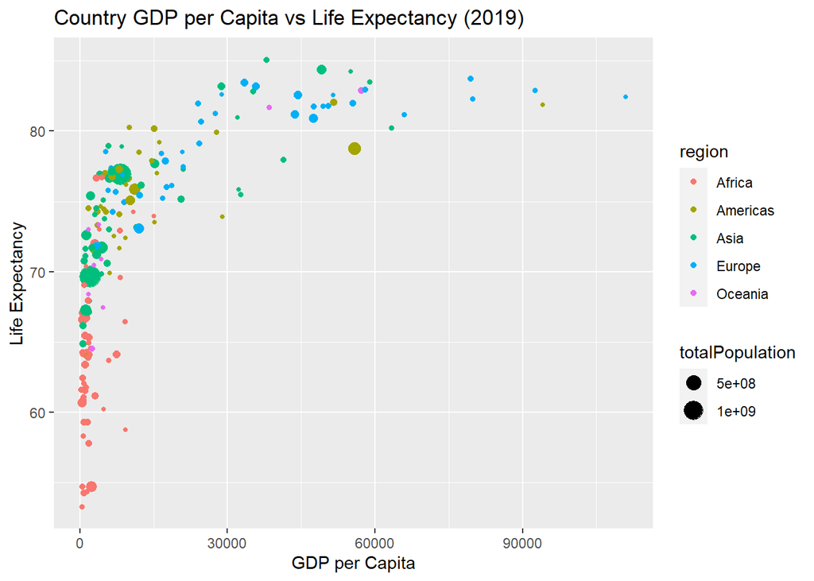

```r
gap_2019 <- gap %>%
  filter(time == "2019",
         !is.na(name),
         !is.na(region),
         !is.na(GDP_PC),
         !is.na(totalPopulation),
         !is.na(lifeExpectancy))

ggplot(gap_2019, aes(GDP_PC, lifeExpectancy)) +
  geom_point(aes(group = region,
                 size = totalPopulation,
                 color = region)) +
  labs(title = "Country GDP per Capita vs Life Expectancy (2019)",
       x = "GDP per Capita",
       y = "Life Expectancy")
```

**3. (6pt) Compare these two plots and comment what do you see. How has world developed through the last 60 years?**  
Compared to that of 1960, it seems that most countries have managed to increase their GDP per capita and life expectancy. We also see an increase in population overall. It’s also interesting to see that some countries seem to have not improved their GDP at all, yet have managed to increase life expectancy. The data in 2019 also appears much tighter, indicating a clearer disparity between regions (such as Africa and Europe) than in 1960.

**4. (6pt) Compute the average life expectancy for each continent in 1960 and 2019. Do the results fit with what do you see on the figures?**  
**Note: here as *average* I mean just average over countries, ignore the fact that countries are of different size.**

```r
gap %>%
  filter(time %in% c("1960", "2019"),
         !is.na(lifeExpectancy),
         !is.na(region)) %>%
  group_by(time, region) %>%
  summarize(avg_LE = mean(lifeExpectancy))
```

```
## # A tibble: 10 × 3
## # Groups:   time [2]
##     time region   avg_LE
##    <dbl> <chr>     <dbl>
##  1  1960 Africa     41.5
##  2  1960 Americas   58.6
##  3  1960 Asia       51.6
##  4  1960 Europe     68.3
##  5  1960 Oceania    56.4
##  6  2019 Africa     64.1
##  7  2019 Americas   75.8
##  8  2019 Asia       74.6
##  9  2019 Europe     79.4
## 10  2019 Oceania    73.5
```

Yes, these computations fit the figures created above because it shows that each region has increased its life expectancy since 1960.

**5. (8pt) Compute the average LE growth from 1960-2019 across the continents. Show the results in the order of growth. Explain what do you see.**  
**Hint: these data (data in long form) is not the simplest to compute growth. But you may want to check out the lag() function. And do not forget to group data by continent when using lag(), otherwise your results will be messed up! See [**https://faculty.washington.edu/otoomet/info201-book/dplyr.html#dplyr-helpers-compute**](https://faculty.washington.edu/otoomet/info201-book/dplyr.html#dplyr-helpers-compute).**

```r
gap %>%
  filter(time %in% c("1960", "2019"),
         !is.na(lifeExpectancy),
         !is.na(region)) %>%
  group_by(region, time) %>%
  summarize(avg_LE = mean(lifeExpectancy)) %>%
  mutate(prev = lag(avg_LE),
         growth = avg_LE - prev) %>%
  arrange(growth)
```

```
## # A tibble: 10 × 5
## # Groups:   region [5]
##    region    time avg_LE  prev growth
##    <chr>    <dbl>  <dbl> <dbl>  <dbl>
##  1 Europe    2019   79.4  68.3   11.1
##  2 Oceania   2019   73.5  56.4   17.1
##  3 Americas  2019   75.8  58.6   17.2
##  4 Africa    2019   64.1  41.5   22.6
##  5 Asia      2019   74.6  51.6   23.0
##  6 Africa    1960   41.5  NA     NA
##  7 Americas  1960   58.6  NA     NA
##  8 Asia      1960   51.6  NA     NA
##  9 Europe    1960   68.3  NA     NA
## 10 Oceania   1960   56.4  NA     NA
```

It seems that Europe had the least growth in average life expectancy, possibly because it’s life expectancy was the highest out of the regions in 1960. This means they probably had little room to grow–whereas countries with a lower life expectancy during 1960 had higher growth.

**6. (6pt) Show the histogram of GDP per capita for years of 1960 and 2019. Try to put both histograms on the same graph, see how well you can do it!**

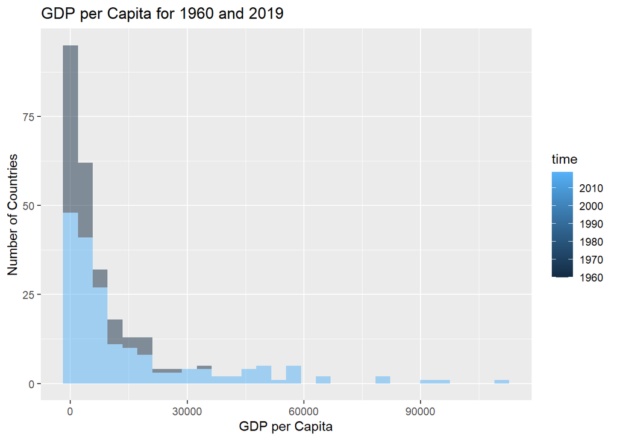

```r
GDP_hist <- gap %>%
  filter(time %in% c("1960", "2019"),
         !is.na(GDP_PC)) %>%
  select(name, time, GDP_PC)

ggplot(GDP_hist) +
  geom_histogram(aes(x = GDP_PC, group = time, fill = time),
                 alpha = 0.5) +
  labs(title = "GDP per Capita for 1960 and 2019",
       x = "GDP per Capita",
       y = "Number of Countries")
```

**7. (6pt) What was the ranking of US in terms of life expectancy in 1960 and in 2019? (When counting from top.)**  
**Hint: check out the function rank()!**  
**Hint2: 17 for 1960.**

```r
ranks <- gap %>%
  filter(time %in% c("1960", "2019"),
         !is.na(name),
         !is.na(lifeExpectancy)) %>%
  select(name, time, lifeExpectancy) %>%
  group_by(time) %>%
  mutate(LE_rank = rank(desc(lifeExpectancy)))

ranks %>%
  filter(name == "United States of America")
```

```
## # A tibble: 2 × 4
## # Groups:   time [2]
##   name                      time lifeExpectancy LE_rank
##   <chr>                    <dbl>          <dbl>   <dbl>
## 1 United States of America  1960           69.8      17
## 2 United States of America  2019           78.8      46
```

The U.S. ranked #17 in life expectancy in 1960 and #46 in 2019.

**8. (6pt) If you did this correctly, then you noticed that US ranking has been falling quite a bit. But we also have more countries in** **2019–what about the relative rank divided by the corresponding number of countries that have LE data in the corresponding year?**  
**Hint: 0.0904 for 1960.**

```r
ranks %>%
  select(name, time, LE_rank) %>%
  group_by(time) %>%
  mutate(total_n = max(LE_rank)) %>%
  filter(name == "United States of America") %>%
  summarize(new_rank = LE_rank/total_n)
```

```
## # A tibble: 2 × 2
##    time new_rank
##   <dbl>    <dbl>
## 1  1960   0.0904
## 2  2019   0.235
```

**Finally tell us how many hours did you spend on this PS.**  
Too many ;-; probably like 10-12 hours.